# Data Science Career Skills

## With Python, Pandas, Plotly, Requests, and Beautiful Soup

## 2019-12-04

```python
# Import necessary libraries
import pandas as pd
import numpy as np
from bs4 import BeautifulSoup as bs
import requests
import matplotlib.pyplot as plt
```

# The Plan

In this Jupyter notebook I'll show you how to scrape the data for job listings from Monster, SimplyHired, and Indeed.

## Scrape the data for 2019

The header and to pass and the search terms to iterate through with "Data Scientist" are below. Add other search terms if you like.

```python
header = {
  "User-Agent": "Mozilla/5.0 (X11; Linux x86_64) AppleWebKit/537.36 (KHTML, like Gecko) Chrome/50.0.2661.75 Safari/537.36",
  "X-Requested-With": "XMLHttpRequest"
}

# read search terms from csv into a list
search_terms = [
"",
"Python",
"SQL",
"R",
"Spark",
"Hadoop",
"Java",
"Tableau",
"AWS",
"SAS",
"Hive",
"Scala",
"Excel",
"TensorFlow",
"C++",
"Azure",
"NoSQL",
"Linux",
"C",
"Matlab",
"Scikit-learn",
"Pandas",
"Git",
"Keras",
"Javascript",
"Pig",
"Hbase",
"Google Cloud",
"Docker",
"NumPy",
"PyTorch",
"C#",
"SPSS",
"MySQL",
"Perl",
"Cassandra",
"MongoDB",
"GCP",
"Kubernetes",
"D3",
"Databricks",
"postgresql",
"Caffe",
"Airflow",
"Alteryx",
"BigQuery",
"Fastai",
]
```

Will have to make changes to C# and C++ manually because those characters get escaped in query strings

# Indeed

Let's use requests to do our scraping and BS4 to get the results that we'll put into a pandas DataFrame.

```python
indeed_list = []

for term in search_terms:
    url = f'https://www.indeed.com/jobs?q=%22data+scientist%22+%22{term}%22&l=United+States'

    try:
        r = requests.get(url, headers=header, timeout=10)
        soup = bs(r.text, 'html.parser')
        count_str = soup.find('div', id="searchCountPages").get_text()
        numb = count_str.split()
        indeed_list.append(numb[-2])
    except Exception as e:
        print(f'error: {e}')

indeed_list
```

```
['5,806',
 '4,305',
 '3,163',
 '3,105',
 '1,691',
 '1,574',
 '1,457',
 '1,147',
 '1,235',
 '965',
 '852',
 '772',
 '606',
 '873',
 '520',
 '626',
 '597',
 '547',
 '520',
 '567',
 '526',
 '360',
 '347',
 '401',
 '283',
 '318',
 '318',
 '181',
 '373',
 '285',
 '323',
 '520',
 '248',
 '237',
 '336',
 '271',
 '234',
 '232',
 '261',
 '131',
 '139',
 '104',
 '171',
 '95',
 '84',
 '133',
 '1']
```

```python
df = pd.DataFrame(indeed_list, index=search_terms, columns=['Indeed'])
```

```python
df.head()
```

|  | Indeed |
| --- | --- |
|  | 5,806 |
| Python | 4,305 |
| SQL | 3,163 |
| R | 3,105 |
| Spark | 1,691 |

```python
df.rename(index={'':'Data Scientist'},inplace=True)
df
```

|  | Indeed |
| --- | --- |
| Data Scientist | 5,806 |
| Python | 4,305 |
| SQL | 3,163 |
| R | 3,105 |
| Spark | 1,691 |
| Hadoop | 1,574 |
| Java | 1,457 |
| Tableau | 1,147 |
| AWS | 1,235 |
| SAS | 965 |
| Hive | 852 |
| Scala | 772 |
| Excel | 606 |
| TensorFlow | 873 |
| C++ | 520 |
| Azure | 626 |
| NoSQL | 597 |
| Linux | 547 |
| C | 520 |
| Matlab | 567 |
| Scikit-learn | 526 |
| Pandas | 360 |
| Git | 347 |
| Keras | 401 |
| Javascript | 283 |
| Pig | 318 |
| Hbase | 318 |
| Google Cloud | 181 |
| Docker | 373 |
| NumPy | 285 |
| PyTorch | 323 |
| C# | 520 |
| SPSS | 248 |
| MySQL | 237 |
| Perl | 336 |
| Cassandra | 271 |
| MongoDB | 234 |
| GCP | 232 |
| Kubernetes | 261 |
| D3 | 131 |
| Databricks | 139 |
| postgresql | 104 |
| Caffe | 171 |
| Airflow | 95 |
| Alteryx | 84 |
| BigQuery | 133 |
| Fastai | 1 |

# Monster

```python
monster_list = []

for term in search_terms:
    url = f'https://www.monster.com/jobs/search/?q=__22data-scientist__22-__22{term}__22'

    try:
        r = requests.get(url, headers=header, timeout=5)
        soup = bs(r.text, 'html.parser')
        count_str = soup.find('h2', class_="figure").get_text()
        numb = count_str.split()
        monster_count = numb[0].replace("(", "")
        monster_list.append(monster_count)
    except Exception as e:
        print(f'error: {e}')

monster_list
```

```
error: 'NoneType' object has no attribute 'get_text'
```

```
['3285',
 '2391',
 '1764',
 '1802',
 '947',
 '962',
 '791',
 '601',
 '586',
 '627',
 '519',
 '472',
 '335',
 '433',
 '382',
 '378',
 '261',
 '327',
 '382',
 '266',
 '255',
 '196',
 '160',
 '210',
 '226',
 '193',
 '78',
 '101',
 '130',
 '166',
 '214',
 '381',
 '147',
 '130',
 '115',
 '82',
 '123',
 '91',
 '89',
 '72',
 '78',
 '130',
 '46',
 '56',
 '59',
 '20']
```

```python
monster_list.append(0) # because no results for fastai. change to check if length matches first.
```

```python
df['Monster'] = monster_list
df
```

|  | Indeed | Monster |
| --- | --- | --- |
| Data Scientist | 5,806 | 3285 |
| Python | 4,305 | 2391 |
| SQL | 3,163 | 1764 |
| R | 3,105 | 1802 |
| Spark | 1,691 | 947 |
| Hadoop | 1,574 | 962 |
| Java | 1,457 | 791 |
| Tableau | 1,147 | 601 |
| AWS | 1,235 | 586 |
| SAS | 965 | 627 |
| Hive | 852 | 519 |
| Scala | 772 | 472 |
| Excel | 606 | 335 |
| TensorFlow | 873 | 433 |
| C++ | 520 | 382 |
| Azure | 626 | 378 |
| NoSQL | 597 | 261 |
| Linux | 547 | 327 |
| C | 520 | 382 |
| Matlab | 567 | 266 |
| Scikit-learn | 526 | 255 |
| Pandas | 360 | 196 |
| Git | 347 | 160 |
| Keras | 401 | 210 |
| Javascript | 283 | 226 |
| Pig | 318 | 193 |
| Hbase | 318 | 78 |
| Google Cloud | 181 | 101 |
| Docker | 373 | 130 |
| NumPy | 285 | 166 |
| PyTorch | 323 | 214 |
| C# | 520 | 381 |
| SPSS | 248 | 147 |
| MySQL | 237 | 130 |
| Perl | 336 | 115 |
| Cassandra | 271 | 82 |
| MongoDB | 234 | 123 |
| GCP | 232 | 91 |
| Kubernetes | 261 | 89 |
| D3 | 131 | 72 |
| Databricks | 139 | 78 |
| postgresql | 104 | 130 |
| Caffe | 171 | 46 |
| Airflow | 95 | 56 |
| Alteryx | 84 | 59 |
| BigQuery | 133 | 20 |
| Fastai | 1 | 0 |

# SimplyHired

```python
simply_list = []

for term in search_terms:
    url = f'https://www.simplyhired.com/search?q=%22data+scientist%22+%22{term}%22&l=United+States'

    try:
        r = requests.get(url, headers=header, timeout=5)
        soup = bs(r.text, 'html.parser')
        count_str = soup.find('span', class_="posting-total").get_text()
        simply_list.append(count_str)
    except Exception as e:
        print(f'error: {e}')

simply_list
```

```
['4,110',
 '3,141',
 '2,249',
 '2,344',
 '1,147',
 '1,070',
 '1,008',
 '883',
 '788',
 '736',
 '561',
 '592',
 '485',
 '586',
 '380',
 '399',
 '366',
 '376',
 '380',
 '458',
 '383',
 '317',
 '267',
 '263',
 '245',
 '198',
 '163',
 '138',
 '189',
 '253',
 '258',
 '380',
 '213',
 '203',
 '169',
 '132',
 '146',
 '116',
 '105',
 '105',
 '90',
 '94',
 '77',
 '77',
 '72',
 '56',
 '1']
```

```python
df['SimplyHired'] = simply_list
df
```

|  | Indeed | Monster | SimplyHired |
| --- | --- | --- | --- |
| Data Scientist | 5,806 | 3285 | 4,110 |
| Python | 4,305 | 2391 | 3,141 |
| SQL | 3,163 | 1764 | 2,249 |
| R | 3,105 | 1802 | 2,344 |
| Spark | 1,691 | 947 | 1,147 |
| Hadoop | 1,574 | 962 | 1,070 |
| Java | 1,457 | 791 | 1,008 |
| Tableau | 1,147 | 601 | 883 |
| AWS | 1,235 | 586 | 788 |
| SAS | 965 | 627 | 736 |
| Hive | 852 | 519 | 561 |
| Scala | 772 | 472 | 592 |
| Excel | 606 | 335 | 485 |
| TensorFlow | 873 | 433 | 586 |
| C++ | 520 | 382 | 380 |
| Azure | 626 | 378 | 399 |
| NoSQL | 597 | 261 | 366 |
| Linux | 547 | 327 | 376 |
| C | 520 | 382 | 380 |
| Matlab | 567 | 266 | 458 |
| Scikit-learn | 526 | 255 | 383 |
| Pandas | 360 | 196 | 317 |
| Git | 347 | 160 | 267 |
| Keras | 401 | 210 | 263 |
| Javascript | 283 | 226 | 245 |
| Pig | 318 | 193 | 198 |
| Hbase | 318 | 78 | 163 |
| Google Cloud | 181 | 101 | 138 |
| Docker | 373 | 130 | 189 |
| NumPy | 285 | 166 | 253 |
| PyTorch | 323 | 214 | 258 |
| C# | 520 | 381 | 380 |
| SPSS | 248 | 147 | 213 |
| MySQL | 237 | 130 | 203 |
| Perl | 336 | 115 | 169 |
| Cassandra | 271 | 82 | 132 |
| MongoDB | 234 | 123 | 146 |
| GCP | 232 | 91 | 116 |
| Kubernetes | 261 | 89 | 105 |
| D3 | 131 | 72 | 105 |
| Databricks | 139 | 78 | 90 |
| postgresql | 104 | 130 | 94 |
| Caffe | 171 | 46 | 77 |
| Airflow | 95 | 56 | 77 |
| Alteryx | 84 | 59 | 72 |
| BigQuery | 133 | 20 | 56 |
| Fastai | 1 | 0 | 1 |

```python
df.info()
```

```
<class 'pandas.core.frame.DataFrame'>
Index: 47 entries, Data Scientist to Fastai
Data columns (total 3 columns):
Indeed         47 non-null object
Monster        47 non-null object
SimplyHired    47 non-null object
dtypes: object(3)
memory usage: 1.5+ KB
```

## Let's make everything numeric.

```python
df = df.apply(lambda x:x.str.replace(',', '').astype(float), axis=1)
df.head()
```

|  | Indeed | Monster | SimplyHired |
| --- | --- | --- | --- |
| Data Scientist | 5806.0 | 3285.0 | 4110.0 |
| Python | 4305.0 | 2391.0 | 3141.0 |
| SQL | 3163.0 | 1764.0 | 2249.0 |
| R | 3105.0 | 1802.0 | 2344.0 |
| Spark | 1691.0 | 947.0 | 1147.0 |

# LinkedIn

You have to be logged in to get exact counts. Could use oath or selenium. My IP appears to have been blocked, despite Supreme Court ruling the folks can scrape. May have hit rate limit. Skip this section if not using LinkedIn.

```python
from selenium import webdriver
from selenium.webdriver.common.keys import Keys
import time
```

```python
userid = 'jeffmshale@gmail.com'
# password = LINKEDIN_PW
```

```python
chrome_path = '.././chromedriver'
driver = webdriver.Chrome(chrome_path)
```

```python
# driver.get("https://www.linkedin.com")
```

### Login

```python
driver.implicitly_wait(6)
driver.find_element_by_name('session_key').send_keys(userid)
driver.find_element_by_name('session_password').send_keys(password)
driver.find_element_by_class_name('sign-in-form__submit-btn').click()
```

```python
# driver.get("https://www.linkedin.com/jobs/search")
driver.implicitly_wait(2)
```

### Scrape

```python
numb_list = []

for term in search_terms[:5]:
    try:
        driver.get("https://www.linkedin.com/jobs/search")
        driver.implicitly_wait(5)
        driver.find_element_by_class_name('jobs-search-box__text-input').send_keys(f'"data scientist" {term}')
        time.sleep(1)
        driver.find_element_by_id('jobs-search-box-location-id-ember58').send_keys('United States')
        time.sleep(1)
        driver.find_element_by_class_name('jobs-search-box__submit-button').click()
        time.sleep(4)
        html = driver.page_source
        soup = bs(html)
        count_str = soup.find('div', class_="jobs-search-two-pane__title").get_text()
        numb = count_str.strip().split()
        numb_list.append(numb[6])


    except Exception as e:
        print(f'error: {e}')

numb_list
```

```
error: list index out of range
error: list index out of range
error: list index out of range
error: list index out of range
error: list index out of range
```

```
[]
```

### Ugh. I've been blocked. Abandoning LinkedIn.

# Analysis

```python
import matplotlib.pyplot as plt
import seaborn as sns
import collections

from IPython.core.display import display, HTML
from sklearn.preprocessing import MinMaxScaler

# import plotly
import plotly
import plotly.figure_factory as ff
import plotly.graph_objs as go
import plotly.offline as py
import plotly.tools as tls

# for color scales in plotly
import colorlover as cl


pd.options.display.float_format = '{:,.2f}'.format
pd.options.display.max_columns = 999

py.init_notebook_mode(connected=True)

%load_ext autoreload
%autoreload 2
%matplotlib inline
```

Total listings with 'Data Scientist' for Indeed, Monster, and SimplyHired

```python
total_ds_jobs = list(df.iloc[0])
total_ds_jobs
```

```
[5806.0, 3285.0, 4110.0]
```

### These are the totals for 2019 for "Data Scientist" alone:

(In case I accidentally rerun the cell)

Data Scientist 5806.0 3285.0 4110.0

```python
df = df.drop('Data Scientist')
df
```

|  | Indeed | Monster | SimplyHired |
| --- | --- | --- | --- |
| Python | 4,305.00 | 2,391.00 | 3,141.00 |
| SQL | 3,163.00 | 1,764.00 | 2,249.00 |
| R | 3,105.00 | 1,802.00 | 2,344.00 |
| Spark | 1,691.00 | 947.00 | 1,147.00 |
| Hadoop | 1,574.00 | 962.00 | 1,070.00 |
| Java | 1,457.00 | 791.00 | 1,008.00 |
| Tableau | 1,147.00 | 601.00 | 883.00 |
| AWS | 1,235.00 | 586.00 | 788.00 |
| SAS | 965.00 | 627.00 | 736.00 |
| Hive | 852.00 | 519.00 | 561.00 |
| Scala | 772.00 | 472.00 | 592.00 |
| Excel | 606.00 | 335.00 | 485.00 |
| TensorFlow | 873.00 | 433.00 | 586.00 |
| C++ | 520.00 | 382.00 | 380.00 |
| Azure | 626.00 | 378.00 | 399.00 |
| NoSQL | 597.00 | 261.00 | 366.00 |
| Linux | 547.00 | 327.00 | 376.00 |
| C | 520.00 | 382.00 | 380.00 |
| Matlab | 567.00 | 266.00 | 458.00 |
| Scikit-learn | 526.00 | 255.00 | 383.00 |
| Pandas | 360.00 | 196.00 | 317.00 |
| Git | 347.00 | 160.00 | 267.00 |
| Keras | 401.00 | 210.00 | 263.00 |
| Javascript | 283.00 | 226.00 | 245.00 |
| Pig | 318.00 | 193.00 | 198.00 |
| Hbase | 318.00 | 78.00 | 163.00 |
| Google Cloud | 181.00 | 101.00 | 138.00 |
| Docker | 373.00 | 130.00 | 189.00 |
| NumPy | 285.00 | 166.00 | 253.00 |
| PyTorch | 323.00 | 214.00 | 258.00 |
| C# | 520.00 | 381.00 | 380.00 |
| SPSS | 248.00 | 147.00 | 213.00 |
| MySQL | 237.00 | 130.00 | 203.00 |
| Perl | 336.00 | 115.00 | 169.00 |
| Cassandra | 271.00 | 82.00 | 132.00 |
| MongoDB | 234.00 | 123.00 | 146.00 |
| GCP | 232.00 | 91.00 | 116.00 |
| Kubernetes | 261.00 | 89.00 | 105.00 |
| D3 | 131.00 | 72.00 | 105.00 |
| Databricks | 139.00 | 78.00 | 90.00 |
| postgresql | 104.00 | 130.00 | 94.00 |
| Caffe | 171.00 | 46.00 | 77.00 |
| Airflow | 95.00 | 56.00 | 77.00 |
| Alteryx | 84.00 | 59.00 | 72.00 |
| BigQuery | 133.00 | 20.00 | 56.00 |
| Fastai | 1.00 | nan | 1.00 |

```python
df = df.fillna(0)
```

Fix C# and C++ with manual numbers 12/4/2019

```python
df.loc['C++'] = [798, 322, 582]
df.loc['C#'] = [335, 159, 176]
df
```

|  | Indeed | Monster | SimplyHired |
| --- | --- | --- | --- |
| Python | 4,305.00 | 2,391.00 | 3,141.00 |
| SQL | 3,163.00 | 1,764.00 | 2,249.00 |
| R | 3,105.00 | 1,802.00 | 2,344.00 |
| Spark | 1,691.00 | 947.00 | 1,147.00 |
| Hadoop | 1,574.00 | 962.00 | 1,070.00 |
| Java | 1,457.00 | 791.00 | 1,008.00 |
| Tableau | 1,147.00 | 601.00 | 883.00 |
| AWS | 1,235.00 | 586.00 | 788.00 |
| SAS | 965.00 | 627.00 | 736.00 |
| Hive | 852.00 | 519.00 | 561.00 |
| Scala | 772.00 | 472.00 | 592.00 |
| Excel | 606.00 | 335.00 | 485.00 |
| TensorFlow | 873.00 | 433.00 | 586.00 |
| C++ | 798.00 | 322.00 | 582.00 |
| Azure | 626.00 | 378.00 | 399.00 |
| NoSQL | 597.00 | 261.00 | 366.00 |
| Linux | 547.00 | 327.00 | 376.00 |
| C | 520.00 | 382.00 | 380.00 |
| Matlab | 567.00 | 266.00 | 458.00 |
| Scikit-learn | 526.00 | 255.00 | 383.00 |
| Pandas | 360.00 | 196.00 | 317.00 |
| Git | 347.00 | 160.00 | 267.00 |
| Keras | 401.00 | 210.00 | 263.00 |
| Javascript | 283.00 | 226.00 | 245.00 |
| Pig | 318.00 | 193.00 | 198.00 |
| Hbase | 318.00 | 78.00 | 163.00 |
| Google Cloud | 181.00 | 101.00 | 138.00 |
| Docker | 373.00 | 130.00 | 189.00 |
| NumPy | 285.00 | 166.00 | 253.00 |
| PyTorch | 323.00 | 214.00 | 258.00 |
| C# | 335.00 | 159.00 | 176.00 |
| SPSS | 248.00 | 147.00 | 213.00 |
| MySQL | 237.00 | 130.00 | 203.00 |
| Perl | 336.00 | 115.00 | 169.00 |
| Cassandra | 271.00 | 82.00 | 132.00 |
| MongoDB | 234.00 | 123.00 | 146.00 |
| GCP | 232.00 | 91.00 | 116.00 |
| Kubernetes | 261.00 | 89.00 | 105.00 |
| D3 | 131.00 | 72.00 | 105.00 |
| Databricks | 139.00 | 78.00 | 90.00 |
| postgresql | 104.00 | 130.00 | 94.00 |
| Caffe | 171.00 | 46.00 | 77.00 |
| Airflow | 95.00 | 56.00 | 77.00 |
| Alteryx | 84.00 | 59.00 | 72.00 |
| BigQuery | 133.00 | 20.00 | 56.00 |
| Fastai | 1.00 | 0.00 | 1.00 |

## Write out file

Get today's date.

```python
import datetime
today = datetime.date.today()
```

```python
df.to_csv(f'tech_skills_{today}.csv')
```

```python
percent_df = df/total_ds_jobs
```

```python
percent_df
```

|  | Indeed | Monster | SimplyHired |
| --- | --- | --- | --- |
| Python | 0.74 | 0.73 | 0.76 |
| SQL | 0.54 | 0.54 | 0.55 |
| R | 0.53 | 0.55 | 0.57 |
| Spark | 0.29 | 0.29 | 0.28 |
| Hadoop | 0.27 | 0.29 | 0.26 |
| Java | 0.25 | 0.24 | 0.25 |
| Tableau | 0.20 | 0.18 | 0.21 |
| AWS | 0.21 | 0.18 | 0.19 |
| SAS | 0.17 | 0.19 | 0.18 |
| Hive | 0.15 | 0.16 | 0.14 |
| Scala | 0.13 | 0.14 | 0.14 |
| Excel | 0.10 | 0.10 | 0.12 |
| TensorFlow | 0.15 | 0.13 | 0.14 |
| C++ | 0.14 | 0.10 | 0.14 |
| Azure | 0.11 | 0.12 | 0.10 |
| NoSQL | 0.10 | 0.08 | 0.09 |
| Linux | 0.09 | 0.10 | 0.09 |
| C | 0.09 | 0.12 | 0.09 |
| Matlab | 0.10 | 0.08 | 0.11 |
| Scikit-learn | 0.09 | 0.08 | 0.09 |
| Pandas | 0.06 | 0.06 | 0.08 |
| Git | 0.06 | 0.05 | 0.06 |
| Keras | 0.07 | 0.06 | 0.06 |
| Javascript | 0.05 | 0.07 | 0.06 |
| Pig | 0.05 | 0.06 | 0.05 |
| Hbase | 0.05 | 0.02 | 0.04 |
| Google Cloud | 0.03 | 0.03 | 0.03 |
| Docker | 0.06 | 0.04 | 0.05 |
| NumPy | 0.05 | 0.05 | 0.06 |
| PyTorch | 0.06 | 0.07 | 0.06 |
| C# | 0.06 | 0.05 | 0.04 |
| SPSS | 0.04 | 0.04 | 0.05 |
| MySQL | 0.04 | 0.04 | 0.05 |
| Perl | 0.06 | 0.04 | 0.04 |
| Cassandra | 0.05 | 0.02 | 0.03 |
| MongoDB | 0.04 | 0.04 | 0.04 |
| GCP | 0.04 | 0.03 | 0.03 |
| Kubernetes | 0.04 | 0.03 | 0.03 |
| D3 | 0.02 | 0.02 | 0.03 |
| Databricks | 0.02 | 0.02 | 0.02 |
| postgresql | 0.02 | 0.04 | 0.02 |
| Caffe | 0.03 | 0.01 | 0.02 |
| Airflow | 0.02 | 0.02 | 0.02 |
| Alteryx | 0.01 | 0.02 | 0.02 |
| BigQuery | 0.02 | 0.01 | 0.01 |
| Fastai | 0.00 | 0.00 | 0.00 |

```python
percent_df['avg'] = percent_df.mean(axis=1)
percent_df
```

|  | Indeed | Monster | SimplyHired | avg |
| --- | --- | --- | --- | --- |
| Python | 0.74 | 0.73 | 0.76 | 0.74 |
| SQL | 0.54 | 0.54 | 0.55 | 0.54 |
| R | 0.53 | 0.55 | 0.57 | 0.55 |
| Spark | 0.29 | 0.29 | 0.28 | 0.29 |
| Hadoop | 0.27 | 0.29 | 0.26 | 0.27 |
| Java | 0.25 | 0.24 | 0.25 | 0.25 |
| Tableau | 0.20 | 0.18 | 0.21 | 0.20 |
| AWS | 0.21 | 0.18 | 0.19 | 0.19 |
| SAS | 0.17 | 0.19 | 0.18 | 0.18 |
| Hive | 0.15 | 0.16 | 0.14 | 0.15 |
| Scala | 0.13 | 0.14 | 0.14 | 0.14 |
| Excel | 0.10 | 0.10 | 0.12 | 0.11 |
| TensorFlow | 0.15 | 0.13 | 0.14 | 0.14 |
| C++ | 0.14 | 0.10 | 0.14 | 0.13 |
| Azure | 0.11 | 0.12 | 0.10 | 0.11 |
| NoSQL | 0.10 | 0.08 | 0.09 | 0.09 |
| Linux | 0.09 | 0.10 | 0.09 | 0.10 |
| C | 0.09 | 0.12 | 0.09 | 0.10 |
| Matlab | 0.10 | 0.08 | 0.11 | 0.10 |
| Scikit-learn | 0.09 | 0.08 | 0.09 | 0.09 |
| Pandas | 0.06 | 0.06 | 0.08 | 0.07 |
| Git | 0.06 | 0.05 | 0.06 | 0.06 |
| Keras | 0.07 | 0.06 | 0.06 | 0.07 |
| Javascript | 0.05 | 0.07 | 0.06 | 0.06 |
| Pig | 0.05 | 0.06 | 0.05 | 0.05 |
| Hbase | 0.05 | 0.02 | 0.04 | 0.04 |
| Google Cloud | 0.03 | 0.03 | 0.03 | 0.03 |
| Docker | 0.06 | 0.04 | 0.05 | 0.05 |
| NumPy | 0.05 | 0.05 | 0.06 | 0.05 |
| PyTorch | 0.06 | 0.07 | 0.06 | 0.06 |
| C# | 0.06 | 0.05 | 0.04 | 0.05 |
| SPSS | 0.04 | 0.04 | 0.05 | 0.05 |
| MySQL | 0.04 | 0.04 | 0.05 | 0.04 |
| Perl | 0.06 | 0.04 | 0.04 | 0.04 |
| Cassandra | 0.05 | 0.02 | 0.03 | 0.03 |
| MongoDB | 0.04 | 0.04 | 0.04 | 0.04 |
| GCP | 0.04 | 0.03 | 0.03 | 0.03 |
| Kubernetes | 0.04 | 0.03 | 0.03 | 0.03 |
| D3 | 0.02 | 0.02 | 0.03 | 0.02 |
| Databricks | 0.02 | 0.02 | 0.02 | 0.02 |
| postgresql | 0.02 | 0.04 | 0.02 | 0.03 |
| Caffe | 0.03 | 0.01 | 0.02 | 0.02 |
| Airflow | 0.02 | 0.02 | 0.02 | 0.02 |
| Alteryx | 0.01 | 0.02 | 0.02 | 0.02 |
| BigQuery | 0.02 | 0.01 | 0.01 | 0.01 |
| Fastai | 0.00 | 0.00 | 0.00 | 0.00 |

# 2018 data

Total listings for "data scientist" for these three sites. I took this data from a .csv file where I put in the results by hand in 2018. It's available at [Kaggle](https://www.kaggle.com/discdiver/the-most-in-demand-skills-for-data-scientists/data).

```python
total_2018 = {
    'Indeed': 5138,
    'SimplyHired': 3829,
    'Monster': 3746,
}
```

values

```python
df_2018 = pd.read_csv('ds_job_listing_software.csv')
```

```python
df_2018.index = df_2018['Keyword']
df_2018
```

| Keyword | Keyword | LinkedIn | Indeed | SimplyHired | Monster | LinkedIn % | Indeed % | SimplyHired % | Monster % | Avg % | GlassDoor Self Reported % 2017 | Difference |
| --- | --- | --- | --- | --- | --- | --- | --- | --- | --- | --- | --- | --- |
| Python | Python | 6,347 | 3,818 | 2,888 | 2,544 | 74% | 74% | 75% | 68% | 73% | 72% | 1% |
| R | R | 4,553 | 3,106 | 2,393 | 2,365 | 53% | 60% | 62% | 63% | 60% | 64% | -4% |
| SQL | SQL | 3,879 | 2,628 | 2,056 | 1,841 | 45% | 51% | 54% | 49% | 50% | 51% | -1% |
| Spark | Spark | 2,169 | 1,551 | 1,167 | 1,062 | 25% | 30% | 30% | 28% | 29% | 27% | 2% |
| Hadoop | Hadoop | 2,142 | 1,578 | 1,164 | 1,200 | 25% | 31% | 30% | 32% | 30% | 39% | -9% |
| Java | Java | 1,944 | 1,377 | 1,059 | 1,002 | 23% | 27% | 28% | 27% | 26% | 33% | -7% |
| SAS | SAS | 1,713 | 1,134 | 910 | 978 | 20% | 22% | 24% | 26% | 23% | 30% | -7% |
| Tableau | Tableau | 1,216 | 1,012 | 780 | 744 | 14% | 20% | 20% | 20% | 19% | 14% | 5% |
| Hive | Hive | 1,182 | 830 | 637 | 619 | 14% | 16% | 17% | 17% | 16% | 17% | -1% |
| Scala | Scala | 1,040 | 739 | 589 | 520 | 12% | 14% | 15% | 14% | 14% | NaN | NaN |
| C++ | C++ | 1,024 | 765 | 580 | 439 | 12% | 15% | 15% | 12% | 13% | NaN | NaN |
| AWS | AWS | 947 | 791 | 607 | 467 | 11% | 15% | 16% | 12% | 14% | NaN | NaN |
| TensorFlow | TensorFlow | 844 | 661 | 501 | 385 | 10% | 13% | 13% | 10% | 12% | NaN | NaN |
| Matlab | Matlab | 806 | 677 | 544 | 419 | 9% | 13% | 14% | 11% | 12% | 20% | -8% |
| C | C | 795 | 492 | 384 | 523 | 9% | 10% | 10% | 14% | 11% | NaN | NaN |
| Excel | Excel | 701 | 569 | 438 | 397 | 8% | 11% | 11% | 11% | 10% | NaN | NaN |
| Linux | Linux | 601 | 517 | 364 | 303 | 7% | 10% | 10% | 8% | 9% | NaN | NaN |
| NoSQL | NoSQL | 598 | 436 | 387 | 362 | 7% | 8% | 10% | 10% | 9% | NaN | NaN |
| Azure | Azure | 578 | 416 | 285 | 272 | 7% | 8% | 7% | 7% | 7% | NaN | NaN |
| Scikit-learn | Scikit-learn | 474 | 402 | 294 | 212 | 6% | 8% | 8% | 6% | 7% | NaN | NaN |
| SPSS | SPSS | 452 | 330 | 273 | 202 | 5% | 6% | 7% | 5% | 6% | NaN | NaN |
| Pandas | Pandas | 421 | 330 | 282 | 175 | 5% | 6% | 7% | 5% | 6% | NaN | NaN |
| Numpy | Numpy | 387 | 257 | 232 | 152 | 4% | 5% | 6% | 4% | 5% | NaN | NaN |
| Pig | Pig | 367 | 296 | 231 | 256 | 4% | 6% | 6% | 7% | 6% | NaN | NaN |
| D3 | D3 | 353 | 149 | 113 | 95 | 4% | 3% | 3% | 3% | 3% | NaN | NaN |
| Keras | Keras | 329 | 253 | 205 | 131 | 4% | 5% | 5% | 3% | 4% | NaN | NaN |
| Javascript | Javascript | 328 | 245 | 214 | 224 | 4% | 5% | 6% | 6% | 5% | NaN | NaN |
| C# | C# | 324 | 245 | 182 | 219 | 4% | 5% | 5% | 6% | 5% | NaN | NaN |
| Perl | Perl | 309 | 258 | 202 | 198 | 4% | 5% | 5% | 5% | 5% | NaN | NaN |
| Hbase | Hbase | 302 | 219 | 167 | 138 | 4% | 4% | 4% | 4% | 4% | NaN | NaN |
| Docker | Docker | 290 | 240 | 148 | 194 | 3% | 5% | 4% | 5% | 4% | NaN | NaN |
| Git | Git | 282 | 261 | 186 | 145 | 3% | 5% | 5% | 4% | 4% | NaN | NaN |
| MySQL | MySQL | 278 | 233 | 187 | 121 | 3% | 5% | 5% | 3% | 4% | NaN | NaN |
| MongoDB | MongoDB | 251 | 196 | 165 | 116 | 3% | 4% | 4% | 3% | 4% | NaN | NaN |
| Cassandra | Cassandra | 236 | 174 | 146 | 136 | 3% | 3% | 4% | 4% | 3% | NaN | NaN |
| PyTorch | PyTorch | 214 | 143 | 131 | 98 | 2% | 3% | 3% | 3% | 3% | NaN | NaN |
| Caffe | Caffe | 206 | 149 | 113 | 96 | 2% | 3% | 3% | 3% | 3% | NaN | NaN |
| NaN | NaN | NaN | NaN | NaN | NaN | NaN | NaN | NaN | NaN | NaN | NaN | NaN |
| Total | Total | 38,882 | 27,477 | 21,204 | 19,350 | NaN | NaN | NaN | NaN | NaN | NaN | NaN |
| NaN | NaN | NaN | NaN | NaN | NaN | NaN | NaN | NaN | NaN | NaN | NaN | NaN |
| "data scientist" alone | "data scientist" alone | 8,610 | 5,138 | 3,829 | 3,746 | NaN | NaN | NaN | NaN | NaN | NaN | NaN |
| NaN | NaN | NaN | NaN | NaN | NaN | NaN | NaN | NaN | NaN | NaN | NaN | NaN |
| "data scientist" "[keyword]" | "data scientist" "[keyword]" | NaN | NaN | NaN | NaN | NaN | NaN | NaN | NaN | NaN | NaN | NaN |
| Oct. 10, 2018 | Oct. 10, 2018 | NaN | NaN | NaN | NaN | NaN | NaN | NaN | NaN | NaN | NaN | NaN |

```python
df_2018_s = df_2018.iloc[:37, 2:5]
df_2018_s
```

| Keyword | Indeed | SimplyHired | Monster |
| --- | --- | --- | --- |
| Python | 3,818 | 2,888 | 2,544 |
| R | 3,106 | 2,393 | 2,365 |
| SQL | 2,628 | 2,056 | 1,841 |
| Spark | 1,551 | 1,167 | 1,062 |
| Hadoop | 1,578 | 1,164 | 1,200 |
| Java | 1,377 | 1,059 | 1,002 |
| SAS | 1,134 | 910 | 978 |
| Tableau | 1,012 | 780 | 744 |
| Hive | 830 | 637 | 619 |
| Scala | 739 | 589 | 520 |
| C++ | 765 | 580 | 439 |
| AWS | 791 | 607 | 467 |
| TensorFlow | 661 | 501 | 385 |
| Matlab | 677 | 544 | 419 |
| C | 492 | 384 | 523 |
| Excel | 569 | 438 | 397 |
| Linux | 517 | 364 | 303 |
| NoSQL | 436 | 387 | 362 |
| Azure | 416 | 285 | 272 |
| Scikit-learn | 402 | 294 | 212 |
| SPSS | 330 | 273 | 202 |
| Pandas | 330 | 282 | 175 |
| Numpy | 257 | 232 | 152 |
| Pig | 296 | 231 | 256 |
| D3 | 149 | 113 | 95 |
| Keras | 253 | 205 | 131 |
| Javascript | 245 | 214 | 224 |
| C# | 245 | 182 | 219 |
| Perl | 258 | 202 | 198 |
| Hbase | 219 | 167 | 138 |
| Docker | 240 | 148 | 194 |
| Git | 261 | 186 | 145 |
| MySQL | 233 | 187 | 121 |
| MongoDB | 196 | 165 | 116 |
| Cassandra | 174 | 146 | 136 |
| PyTorch | 143 | 131 | 98 |
| Caffe | 149 | 113 | 96 |

```python
df_2018_s = df_2018_s.apply(lambda x:x.str.replace(',', '').astype(float), axis=1)
df_2018_s.head()
```

| Keyword | Indeed | SimplyHired | Monster |
| --- | --- | --- | --- |
| Python | 3,818.00 | 2,888.00 | 2,544.00 |
| R | 3,106.00 | 2,393.00 | 2,365.00 |
| SQL | 2,628.00 | 2,056.00 | 1,841.00 |
| Spark | 1,551.00 | 1,167.00 | 1,062.00 |
| Hadoop | 1,578.00 | 1,164.00 | 1,200.00 |

```python
df_2018_percent = df_2018_s/total_2018
df_2018_percent
```

| Keyword | Indeed | SimplyHired | Monster |
| --- | --- | --- | --- |
| Python | 0.74 | 0.75 | 0.68 |
| R | 0.60 | 0.62 | 0.63 |
| SQL | 0.51 | 0.54 | 0.49 |
| Spark | 0.30 | 0.30 | 0.28 |
| Hadoop | 0.31 | 0.30 | 0.32 |
| Java | 0.27 | 0.28 | 0.27 |
| SAS | 0.22 | 0.24 | 0.26 |
| Tableau | 0.20 | 0.20 | 0.20 |
| Hive | 0.16 | 0.17 | 0.17 |
| Scala | 0.14 | 0.15 | 0.14 |
| C++ | 0.15 | 0.15 | 0.12 |
| AWS | 0.15 | 0.16 | 0.12 |
| TensorFlow | 0.13 | 0.13 | 0.10 |
| Matlab | 0.13 | 0.14 | 0.11 |
| C | 0.10 | 0.10 | 0.14 |
| Excel | 0.11 | 0.11 | 0.11 |
| Linux | 0.10 | 0.10 | 0.08 |
| NoSQL | 0.08 | 0.10 | 0.10 |
| Azure | 0.08 | 0.07 | 0.07 |
| Scikit-learn | 0.08 | 0.08 | 0.06 |
| SPSS | 0.06 | 0.07 | 0.05 |
| Pandas | 0.06 | 0.07 | 0.05 |
| Numpy | 0.05 | 0.06 | 0.04 |
| Pig | 0.06 | 0.06 | 0.07 |
| D3 | 0.03 | 0.03 | 0.03 |
| Keras | 0.05 | 0.05 | 0.03 |
| Javascript | 0.05 | 0.06 | 0.06 |
| C# | 0.05 | 0.05 | 0.06 |
| Perl | 0.05 | 0.05 | 0.05 |
| Hbase | 0.04 | 0.04 | 0.04 |
| Docker | 0.05 | 0.04 | 0.05 |
| Git | 0.05 | 0.05 | 0.04 |
| MySQL | 0.05 | 0.05 | 0.03 |
| MongoDB | 0.04 | 0.04 | 0.03 |
| Cassandra | 0.03 | 0.04 | 0.04 |
| PyTorch | 0.03 | 0.03 | 0.03 |
| Caffe | 0.03 | 0.03 | 0.03 |

### Make the average for 2018.

```python
df_2018_percent['avg'] = df_2018_percent.mean(axis=1)
df_2018_percent
```

| Keyword | Indeed | SimplyHired | Monster | avg |
| --- | --- | --- | --- | --- |
| Python | 0.74 | 0.75 | 0.68 | 0.73 |
| R | 0.60 | 0.62 | 0.63 | 0.62 |
| SQL | 0.51 | 0.54 | 0.49 | 0.51 |
| Spark | 0.30 | 0.30 | 0.28 | 0.30 |
| Hadoop | 0.31 | 0.30 | 0.32 | 0.31 |
| Java | 0.27 | 0.28 | 0.27 | 0.27 |
| SAS | 0.22 | 0.24 | 0.26 | 0.24 |
| Tableau | 0.20 | 0.20 | 0.20 | 0.20 |
| Hive | 0.16 | 0.17 | 0.17 | 0.16 |
| Scala | 0.14 | 0.15 | 0.14 | 0.15 |
| C++ | 0.15 | 0.15 | 0.12 | 0.14 |
| AWS | 0.15 | 0.16 | 0.12 | 0.15 |
| TensorFlow | 0.13 | 0.13 | 0.10 | 0.12 |
| Matlab | 0.13 | 0.14 | 0.11 | 0.13 |
| C | 0.10 | 0.10 | 0.14 | 0.11 |
| Excel | 0.11 | 0.11 | 0.11 | 0.11 |
| Linux | 0.10 | 0.10 | 0.08 | 0.09 |
| NoSQL | 0.08 | 0.10 | 0.10 | 0.09 |
| Azure | 0.08 | 0.07 | 0.07 | 0.08 |
| Scikit-learn | 0.08 | 0.08 | 0.06 | 0.07 |
| SPSS | 0.06 | 0.07 | 0.05 | 0.06 |
| Pandas | 0.06 | 0.07 | 0.05 | 0.06 |
| Numpy | 0.05 | 0.06 | 0.04 | 0.05 |
| Pig | 0.06 | 0.06 | 0.07 | 0.06 |
| D3 | 0.03 | 0.03 | 0.03 | 0.03 |
| Keras | 0.05 | 0.05 | 0.03 | 0.05 |
| Javascript | 0.05 | 0.06 | 0.06 | 0.05 |
| C# | 0.05 | 0.05 | 0.06 | 0.05 |
| Perl | 0.05 | 0.05 | 0.05 | 0.05 |
| Hbase | 0.04 | 0.04 | 0.04 | 0.04 |
| Docker | 0.05 | 0.04 | 0.05 | 0.05 |
| Git | 0.05 | 0.05 | 0.04 | 0.05 |
| MySQL | 0.05 | 0.05 | 0.03 | 0.04 |
| MongoDB | 0.04 | 0.04 | 0.03 | 0.04 |
| Cassandra | 0.03 | 0.04 | 0.04 | 0.04 |
| PyTorch | 0.03 | 0.03 | 0.03 | 0.03 |
| Caffe | 0.03 | 0.03 | 0.03 | 0.03 |

## Merge the 2018 and 2019 DataFrames for Analysis

```python
df_combo = df_2018_percent.merge(percent_df, left_index=True, right_index=True, how='outer')
df_combo
```

|  | Indeed_x | SimplyHired_x | Monster_x | avg_x | Indeed_y | Monster_y | SimplyHired_y | avg_y |
| --- | --- | --- | --- | --- | --- | --- | --- | --- |
| AWS | 0.15 | 0.16 | 0.12 | 0.15 | 0.21 | 0.18 | 0.19 | 0.19 |
| Airflow | nan | nan | nan | nan | 0.02 | 0.02 | 0.02 | 0.02 |
| Alteryx | nan | nan | nan | nan | 0.01 | 0.02 | 0.02 | 0.02 |
| Azure | 0.08 | 0.07 | 0.07 | 0.08 | 0.11 | 0.12 | 0.10 | 0.11 |
| BigQuery | nan | nan | nan | nan | 0.02 | 0.01 | 0.01 | 0.01 |
| C | 0.10 | 0.10 | 0.14 | 0.11 | 0.09 | 0.12 | 0.09 | 0.10 |
| C# | nan | nan | nan | nan | 0.06 | 0.05 | 0.04 | 0.05 |
| C# | 0.05 | 0.05 | 0.06 | 0.05 | nan | nan | nan | nan |
| C++ | 0.15 | 0.15 | 0.12 | 0.14 | 0.14 | 0.10 | 0.14 | 0.13 |
| Caffe | 0.03 | 0.03 | 0.03 | 0.03 | 0.03 | 0.01 | 0.02 | 0.02 |
| Cassandra | 0.03 | 0.04 | 0.04 | 0.04 | 0.05 | 0.02 | 0.03 | 0.03 |
| D3 | 0.03 | 0.03 | 0.03 | 0.03 | 0.02 | 0.02 | 0.03 | 0.02 |
| Databricks | nan | nan | nan | nan | 0.02 | 0.02 | 0.02 | 0.02 |
| Docker | 0.05 | 0.04 | 0.05 | 0.05 | 0.06 | 0.04 | 0.05 | 0.05 |
| Excel | 0.11 | 0.11 | 0.11 | 0.11 | 0.10 | 0.10 | 0.12 | 0.11 |
| Fastai | nan | nan | nan | nan | 0.00 | 0.00 | 0.00 | 0.00 |
| GCP | nan | nan | nan | nan | 0.04 | 0.03 | 0.03 | 0.03 |
| Git | 0.05 | 0.05 | 0.04 | 0.05 | 0.06 | 0.05 | 0.06 | 0.06 |
| Google Cloud | nan | nan | nan | nan | 0.03 | 0.03 | 0.03 | 0.03 |
| Hadoop | 0.31 | 0.30 | 0.32 | 0.31 | 0.27 | 0.29 | 0.26 | 0.27 |
| Hbase | 0.04 | 0.04 | 0.04 | 0.04 | 0.05 | 0.02 | 0.04 | 0.04 |
| Hive | 0.16 | 0.17 | 0.17 | 0.16 | 0.15 | 0.16 | 0.14 | 0.15 |
| Java | 0.27 | 0.28 | 0.27 | 0.27 | 0.25 | 0.24 | 0.25 | 0.25 |
| Javascript | 0.05 | 0.06 | 0.06 | 0.05 | 0.05 | 0.07 | 0.06 | 0.06 |
| Keras | 0.05 | 0.05 | 0.03 | 0.05 | 0.07 | 0.06 | 0.06 | 0.07 |
| Kubernetes | nan | nan | nan | nan | 0.04 | 0.03 | 0.03 | 0.03 |
| Linux | 0.10 | 0.10 | 0.08 | 0.09 | 0.09 | 0.10 | 0.09 | 0.10 |
| Matlab | 0.13 | 0.14 | 0.11 | 0.13 | 0.10 | 0.08 | 0.11 | 0.10 |
| MongoDB | 0.04 | 0.04 | 0.03 | 0.04 | 0.04 | 0.04 | 0.04 | 0.04 |
| MySQL | 0.05 | 0.05 | 0.03 | 0.04 | 0.04 | 0.04 | 0.05 | 0.04 |
| NoSQL | 0.08 | 0.10 | 0.10 | 0.09 | 0.10 | 0.08 | 0.09 | 0.09 |
| NumPy | nan | nan | nan | nan | 0.05 | 0.05 | 0.06 | 0.05 |
| Numpy | 0.05 | 0.06 | 0.04 | 0.05 | nan | nan | nan | nan |
| Pandas | 0.06 | 0.07 | 0.05 | 0.06 | 0.06 | 0.06 | 0.08 | 0.07 |
| Perl | 0.05 | 0.05 | 0.05 | 0.05 | 0.06 | 0.04 | 0.04 | 0.04 |
| Pig | 0.06 | 0.06 | 0.07 | 0.06 | 0.05 | 0.06 | 0.05 | 0.05 |
| PyTorch | 0.03 | 0.03 | 0.03 | 0.03 | 0.06 | 0.07 | 0.06 | 0.06 |
| Python | 0.74 | 0.75 | 0.68 | 0.73 | 0.74 | 0.73 | 0.76 | 0.74 |
| R | 0.60 | 0.62 | 0.63 | 0.62 | 0.53 | 0.55 | 0.57 | 0.55 |
| SAS | 0.22 | 0.24 | 0.26 | 0.24 | 0.17 | 0.19 | 0.18 | 0.18 |
| SPSS | 0.06 | 0.07 | 0.05 | 0.06 | 0.04 | 0.04 | 0.05 | 0.05 |
| SQL | 0.51 | 0.54 | 0.49 | 0.51 | 0.54 | 0.54 | 0.55 | 0.54 |
| Scala | 0.14 | 0.15 | 0.14 | 0.15 | 0.13 | 0.14 | 0.14 | 0.14 |
| Scikit-learn | 0.08 | 0.08 | 0.06 | 0.07 | 0.09 | 0.08 | 0.09 | 0.09 |
| Spark | 0.30 | 0.30 | 0.28 | 0.30 | 0.29 | 0.29 | 0.28 | 0.29 |
| Tableau | 0.20 | 0.20 | 0.20 | 0.20 | 0.20 | 0.18 | 0.21 | 0.20 |
| TensorFlow | 0.13 | 0.13 | 0.10 | 0.12 | 0.15 | 0.13 | 0.14 | 0.14 |
| postgresql | nan | nan | nan | nan | 0.02 | 0.04 | 0.02 | 0.03 |

```python
df_combo = df_combo.loc[:, ['avg_x', 'avg_y']]
df_combo.columns=['2018', '2019']
```

```python
df_combo = df_combo.sort_values(by='2019', ascending=False)
df_combo
```

|  | 2018 | 2019 |
| --- | --- | --- |
| Python | 0.73 | 0.74 |
| R | 0.62 | 0.55 |
| SQL | 0.51 | 0.54 |
| Spark | 0.30 | 0.29 |
| Hadoop | 0.31 | 0.27 |
| Java | 0.27 | 0.25 |
| Tableau | 0.20 | 0.20 |
| AWS | 0.15 | 0.19 |
| SAS | 0.24 | 0.18 |
| Hive | 0.16 | 0.15 |
| TensorFlow | 0.12 | 0.14 |
| Scala | 0.15 | 0.14 |
| C++ | 0.14 | 0.13 |
| Excel | 0.11 | 0.11 |
| Azure | 0.08 | 0.11 |
| C | 0.11 | 0.10 |
| Matlab | 0.13 | 0.10 |
| Linux | 0.09 | 0.10 |
| NoSQL | 0.09 | 0.09 |
| Scikit-learn | 0.07 | 0.09 |
| Pandas | 0.06 | 0.07 |
| Keras | 0.05 | 0.07 |
| PyTorch | 0.03 | 0.06 |
| Javascript | 0.05 | 0.06 |
| Git | 0.05 | 0.06 |
| Pig | 0.06 | 0.05 |
| NumPy | nan | 0.05 |
| Docker | 0.05 | 0.05 |
| C# | nan | 0.05 |
| SPSS | 0.06 | 0.05 |
| Perl | 0.05 | 0.04 |
| MySQL | 0.04 | 0.04 |
| Hbase | 0.04 | 0.04 |
| MongoDB | 0.04 | 0.04 |
| Cassandra | 0.04 | 0.03 |
| Kubernetes | nan | 0.03 |
| GCP | nan | 0.03 |
| Google Cloud | nan | 0.03 |
| postgresql | nan | 0.03 |
| D3 | 0.03 | 0.02 |
| Databricks | nan | 0.02 |
| Caffe | 0.03 | 0.02 |
| Airflow | nan | 0.02 |
| Alteryx | nan | 0.02 |
| BigQuery | nan | 0.01 |
| Fastai | nan | 0.00 |
| C# | 0.05 | nan |
| Numpy | 0.05 | nan |

### Combine two versions of NumPy and C

```python
df_combo.loc["NumPy", "2018"] = df_combo.loc['Numpy', '2018']
df_combo.drop('Numpy')
```

|  | 2018 | 2019 |
| --- | --- | --- |
| Python | 0.73 | 0.74 |
| R | 0.62 | 0.55 |
| SQL | 0.51 | 0.54 |
| Spark | 0.30 | 0.29 |
| Hadoop | 0.31 | 0.27 |
| Java | 0.27 | 0.25 |
| Tableau | 0.20 | 0.20 |
| AWS | 0.15 | 0.19 |
| SAS | 0.24 | 0.18 |
| Hive | 0.16 | 0.15 |
| TensorFlow | 0.12 | 0.14 |
| Scala | 0.15 | 0.14 |
| C++ | 0.14 | 0.13 |
| Excel | 0.11 | 0.11 |
| Azure | 0.08 | 0.11 |
| C | 0.11 | 0.10 |
| Matlab | 0.13 | 0.10 |
| Linux | 0.09 | 0.10 |
| NoSQL | 0.09 | 0.09 |
| Scikit-learn | 0.07 | 0.09 |
| Pandas | 0.06 | 0.07 |
| Keras | 0.05 | 0.07 |
| PyTorch | 0.03 | 0.06 |
| Javascript | 0.05 | 0.06 |
| Git | 0.05 | 0.06 |
| Pig | 0.06 | 0.05 |
| NumPy | 0.05 | 0.05 |
| Docker | 0.05 | 0.05 |
| C# | nan | 0.05 |
| SPSS | 0.06 | 0.05 |
| Perl | 0.05 | 0.04 |
| MySQL | 0.04 | 0.04 |
| Hbase | 0.04 | 0.04 |
| MongoDB | 0.04 | 0.04 |
| Cassandra | 0.04 | 0.03 |
| Kubernetes | nan | 0.03 |
| GCP | nan | 0.03 |
| Google Cloud | nan | 0.03 |
| postgresql | nan | 0.03 |
| D3 | 0.03 | 0.02 |
| Databricks | nan | 0.02 |
| Caffe | 0.03 | 0.02 |
| Airflow | nan | 0.02 |
| Alteryx | nan | 0.02 |
| BigQuery | nan | 0.01 |
| Fastai | nan | 0.00 |
| C# | 0.05 | nan |

```python
df_combo.loc["C#", "2018"] = df_combo.loc['C# ', '2018']
df_combo.drop('C# ')
df_combo
```

|  | 2018 | 2019 |
| --- | --- | --- |
| Python | 0.73 | 0.74 |
| R | 0.62 | 0.55 |
| SQL | 0.51 | 0.54 |
| Spark | 0.30 | 0.29 |
| Hadoop | 0.31 | 0.27 |
| Java | 0.27 | 0.25 |
| Tableau | 0.20 | 0.20 |
| AWS | 0.15 | 0.19 |
| SAS | 0.24 | 0.18 |
| Hive | 0.16 | 0.15 |
| TensorFlow | 0.12 | 0.14 |
| Scala | 0.15 | 0.14 |
| C++ | 0.14 | 0.13 |
| Excel | 0.11 | 0.11 |
| Azure | 0.08 | 0.11 |
| C | 0.11 | 0.10 |
| Matlab | 0.13 | 0.10 |
| Linux | 0.09 | 0.10 |
| NoSQL | 0.09 | 0.09 |
| Scikit-learn | 0.07 | 0.09 |
| Pandas | 0.06 | 0.07 |
| Keras | 0.05 | 0.07 |
| PyTorch | 0.03 | 0.06 |
| Javascript | 0.05 | 0.06 |
| Git | 0.05 | 0.06 |
| Pig | 0.06 | 0.05 |
| NumPy | 0.05 | 0.05 |
| Docker | 0.05 | 0.05 |
| C# | 0.05 | 0.05 |
| SPSS | 0.06 | 0.05 |
| Perl | 0.05 | 0.04 |
| MySQL | 0.04 | 0.04 |
| Hbase | 0.04 | 0.04 |
| MongoDB | 0.04 | 0.04 |
| Cassandra | 0.04 | 0.03 |
| Kubernetes | nan | 0.03 |
| GCP | nan | 0.03 |
| Google Cloud | nan | 0.03 |
| postgresql | nan | 0.03 |
| D3 | 0.03 | 0.02 |
| Databricks | nan | 0.02 |
| Caffe | 0.03 | 0.02 |
| Airflow | nan | 0.02 |
| Alteryx | nan | 0.02 |
| BigQuery | nan | 0.01 |
| Fastai | nan | 0.00 |
| C# | 0.05 | nan |
| Numpy | 0.05 | nan |

Strange, might be a white space with issue the second C#. Oh well, it won't get included here in a second anyway.

### Top 20

```python
df_20 = df_combo.iloc[:20]
df_20
```

|  | 2018 | 2019 |
| --- | --- | --- |
| Python | 0.73 | 0.74 |
| R | 0.62 | 0.55 |
| SQL | 0.51 | 0.54 |
| Spark | 0.30 | 0.29 |
| Hadoop | 0.31 | 0.27 |
| Java | 0.27 | 0.25 |
| Tableau | 0.20 | 0.20 |
| AWS | 0.15 | 0.19 |
| SAS | 0.24 | 0.18 |
| Hive | 0.16 | 0.15 |
| TensorFlow | 0.12 | 0.14 |
| Scala | 0.15 | 0.14 |
| C++ | 0.14 | 0.13 |
| Excel | 0.11 | 0.11 |
| Azure | 0.08 | 0.11 |
| C | 0.11 | 0.10 |
| Matlab | 0.13 | 0.10 |
| Linux | 0.09 | 0.10 |
| NoSQL | 0.09 | 0.09 |
| Scikit-learn | 0.07 | 0.09 |

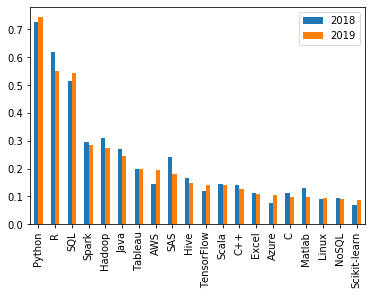

```python
df_20.plot(kind='bar')
```

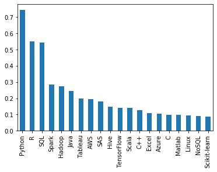

```python
df_2019 = df_20['2019']
df_2019.plot(kind='bar')
```

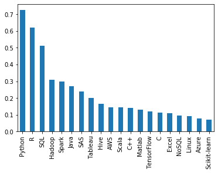

```python
df_2018_sorted = df_20['2018'].sort_values(ascending=False)
df_2018_sorted.plot(kind='bar')
```

# Let's make pretty, interactive charts in Plotly!

```python
cmax=200
cmin=50
color_s = np.linspace(cmin, cmax, 20)

data = [
    go.Bar(
        x=df_20.index,
        y=df_20['2019']*100,
        marker=dict(
            colorscale='Jet',
            color=color_s
        ),
    )
]

layout = {
     'title': 'Technologies in Data Scientist Job Listings 2019',
    'yaxis': {'title': 'Avg % of Listings', },
    'xaxis': {'title': "Technology", 'tickmode': 'linear'},
    'title_x':0.5,
    'height': 500

}

fig = go.Figure(data=data, layout=layout)
py.iplot(fig)
```

[interactive chart not shown]

## Top 15

```python
df_15 = df_combo.iloc[:15]
df_15
```

|  | 2018 | 2019 |
| --- | --- | --- |
| Python | 0.73 | 0.74 |
| R | 0.62 | 0.55 |
| SQL | 0.51 | 0.54 |
| Spark | 0.30 | 0.29 |
| Hadoop | 0.31 | 0.27 |
| Java | 0.27 | 0.25 |
| Tableau | 0.20 | 0.20 |
| AWS | 0.15 | 0.19 |
| SAS | 0.24 | 0.18 |
| Hive | 0.16 | 0.15 |
| TensorFlow | 0.12 | 0.14 |
| Scala | 0.15 | 0.14 |
| C++ | 0.14 | 0.13 |
| Excel | 0.11 | 0.11 |
| Azure | 0.08 | 0.11 |

```python
cmax=200
cmin=50
color_s = np.linspace(cmin, cmax, 15)

data = [
    go.Bar(
        x=df_15.index,
        y=df_15['2019']*100,
        marker=dict(
            colorscale='Jet',
            color=color_s
        ),
    )
]

layout = {
     'title': 'Technologies in Data Scientist Job Listings 2019',
    'yaxis': {'title': 'Avg % of Listings', },
    'xaxis': {'title': "Technology", 'tickmode': 'linear'},
    'title_x':0.5,
    'height': 500

}

fig = go.Figure(data=data, layout=layout)
py.iplot(fig)
```

[interactive chart not shown]

# Looking at just the top 10 for 2019

```python
df_10 = df_combo.iloc[:10]
df_10
```

|  | 2018 | 2019 |
| --- | --- | --- |
| Python | 0.73 | 0.74 |
| R | 0.62 | 0.55 |
| SQL | 0.51 | 0.54 |
| Spark | 0.30 | 0.29 |
| Hadoop | 0.31 | 0.27 |
| Java | 0.27 | 0.25 |
| Tableau | 0.20 | 0.20 |
| AWS | 0.15 | 0.19 |
| SAS | 0.24 | 0.18 |
| Hive | 0.16 | 0.15 |

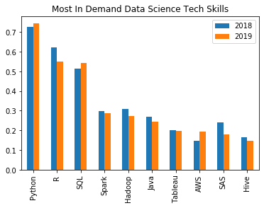

```python
df_10.plot(kind='bar', title='Most In Demand Data Science Tech Skills')
```

```python
df_10 = df_10.sort_values(by='2019')
```

```python
cmax=50
cmin=200
color_s = np.linspace(cmin, cmax, 10)

data = [
    go.Bar(
        y=df_10.index,
        x=df_10['2019'] * 100,
        orientation='h',
        marker=dict(
            colorscale='Jet',
            color=color_s
        ),
    )
]

layout = {
    'title': 'Technologies in Data Scientist Job Listings 2019',
    'yaxis': {'title': 'Software', 'tickmode': 'linear'},
    'xaxis': {'title': "Avg % of Listings"},
    'title_x':0.5,
    'height': 500

}

fig = go.Figure(data=data, layout=layout)
py.iplot(fig)
```

[interactive chart not shown]

# Bigger DF with at least 5% of listings average in 2019

```python
df_over_five = df_combo[df_combo['2019']>=.05]
df_over_five
```

|  | 2018 | 2019 |
| --- | --- | --- |
| Python | 0.73 | 0.74 |
| R | 0.62 | 0.55 |
| SQL | 0.51 | 0.54 |
| Spark | 0.30 | 0.29 |
| Hadoop | 0.31 | 0.27 |
| Java | 0.27 | 0.25 |
| Tableau | 0.20 | 0.20 |
| AWS | 0.15 | 0.19 |
| SAS | 0.24 | 0.18 |
| Hive | 0.16 | 0.15 |
| TensorFlow | 0.12 | 0.14 |
| Scala | 0.15 | 0.14 |
| C++ | 0.14 | 0.13 |
| Excel | 0.11 | 0.11 |
| Azure | 0.08 | 0.11 |
| C | 0.11 | 0.10 |
| Matlab | 0.13 | 0.10 |
| Linux | 0.09 | 0.10 |
| NoSQL | 0.09 | 0.09 |
| Scikit-learn | 0.07 | 0.09 |
| Pandas | 0.06 | 0.07 |
| Keras | 0.05 | 0.07 |
| PyTorch | 0.03 | 0.06 |
| Javascript | 0.05 | 0.06 |
| Git | 0.05 | 0.06 |
| Pig | 0.06 | 0.05 |
| NumPy | 0.05 | 0.05 |

## 2018 Averages Chart

```python
df_over_five_g = df_over_five.sort_values(by='2018', ascending=True)
```

```python
cmax=50
cmin=200
color_s = np.linspace(cmin, cmax, 30)

data = [
    go.Bar(
        y=df_over_five_g.index,
        x=df_over_five_g['2018']*100,
        orientation='h',
        marker=dict(
            colorscale='Jet',
            color=color_s
        ),
    )
]

layout = {
    'title': 'Technologies in Data Scientist Job Listings 2018',
    'xaxis': {'title': 'Avg % of Listings', },
    'yaxis': {'tickmode': 'linear'},
    'title_x':0.5,
    'height': 700

}

fig = go.Figure(data=data, layout=layout)
py.iplot(fig)
```

[interactive chart not shown]

## 2019 Averages Chart

```python
df_over_five_g = df_over_five.sort_values(by='2019', ascending=True)
```

```python
cmax=50
cmin=200
color_s = np.linspace(cmin, cmax, 30)

data = [
    go.Bar(
        y=df_over_five_g.index,
        x=df_over_five_g['2019']*100,
        orientation='h',
        marker=dict(
            colorscale='Jet',
            color=color_s
        ),
    )
]

layout = {
    'title': 'Technologies in Data Scientist Job Listings 2019',
    'xaxis': {'title': 'Avg % of Listings', },
    'yaxis': {'tickmode': 'linear'},
    'title_x':0.5,
    'height': 700

}

fig = go.Figure(data=data, layout=layout)
py.iplot(fig)
```

[interactive chart not shown]

## Compute % change

```python
df_over_five_changes = df_over_five.copy()
df_over_five_changes['Change in Avg'] = df_over_five_changes['2019'] - df_over_five_changes['2018']
df_over_five_changes =  df_over_five_changes.sort_values(by = 'Change in Avg', ascending=False)
df_over_five_changes
```

|  | 2018 | 2019 | Change in Avg |
| --- | --- | --- | --- |
| AWS | 0.15 | 0.19 | 0.05 |
| PyTorch | 0.03 | 0.06 | 0.03 |
| Azure | 0.08 | 0.11 | 0.03 |
| SQL | 0.51 | 0.54 | 0.03 |
| TensorFlow | 0.12 | 0.14 | 0.02 |
| Keras | 0.05 | 0.07 | 0.02 |
| Python | 0.73 | 0.74 | 0.02 |
| Scikit-learn | 0.07 | 0.09 | 0.02 |
| Git | 0.05 | 0.06 | 0.01 |
| Pandas | 0.06 | 0.07 | 0.00 |
| Javascript | 0.05 | 0.06 | 0.00 |
| NumPy | 0.05 | 0.05 | 0.00 |
| Linux | 0.09 | 0.10 | 0.00 |
| Tableau | 0.20 | 0.20 | -0.00 |
| Excel | 0.11 | 0.11 | -0.00 |
| NoSQL | 0.09 | 0.09 | -0.00 |
| Scala | 0.15 | 0.14 | -0.01 |
| Pig | 0.06 | 0.05 | -0.01 |
| Spark | 0.30 | 0.29 | -0.01 |
| C | 0.11 | 0.10 | -0.01 |
| C++ | 0.14 | 0.13 | -0.01 |
| Hive | 0.16 | 0.15 | -0.02 |
| Java | 0.27 | 0.25 | -0.03 |
| Matlab | 0.13 | 0.10 | -0.03 |
| Hadoop | 0.31 | 0.27 | -0.04 |
| SAS | 0.24 | 0.18 | -0.06 |
| R | 0.62 | 0.55 | -0.07 |

```python
pct_change = df_over_five.pct_change(axis=1).sort_values(by='2019', ascending=True)
pct_change
```

|  | 2018 | 2019 |
| --- | --- | --- |
| SAS | nan | -0.25 |
| Matlab | nan | -0.25 |
| Pig | nan | -0.13 |
| Hadoop | nan | -0.12 |
| R | nan | -0.11 |
| C | nan | -0.11 |
| Hive | nan | -0.11 |
| C++ | nan | -0.10 |
| Java | nan | -0.09 |
| NoSQL | nan | -0.04 |
| Scala | nan | -0.04 |
| Spark | nan | -0.04 |
| Excel | nan | -0.02 |
| Tableau | nan | -0.01 |
| Python | nan | 0.03 |
| Linux | nan | 0.03 |
| SQL | nan | 0.06 |
| NumPy | nan | 0.07 |
| Pandas | nan | 0.08 |
| Javascript | nan | 0.08 |
| TensorFlow | nan | 0.17 |
| Scikit-learn | nan | 0.24 |
| Git | nan | 0.26 |
| AWS | nan | 0.33 |
| Azure | nan | 0.40 |
| Keras | nan | 0.43 |
| PyTorch | nan | 1.08 |

```python
pct_change = pct_change.drop('2018', axis=1)
pct_change.columns = ['% Change']
pct_change
```

|  | % Change |
| --- | --- |
| SAS | -0.25 |
| Matlab | -0.25 |
| Pig | -0.13 |
| Hadoop | -0.12 |
| R | -0.11 |
| C | -0.11 |
| Hive | -0.11 |
| C++ | -0.10 |
| Java | -0.09 |
| NoSQL | -0.04 |
| Scala | -0.04 |
| Spark | -0.04 |
| Excel | -0.02 |
| Tableau | -0.01 |
| Python | 0.03 |
| Linux | 0.03 |
| SQL | 0.06 |
| NumPy | 0.07 |
| Pandas | 0.08 |
| Javascript | 0.08 |
| TensorFlow | 0.17 |
| Scikit-learn | 0.24 |
| Git | 0.26 |
| AWS | 0.33 |
| Azure | 0.40 |
| Keras | 0.43 |
| PyTorch | 1.08 |

## DataFrame for medium article

```python
df_over_five_all = df_over_five_changes.merge(pct_change, right_index=True, left_index=True)
df_over_five_all = df_over_five_all * 100
df_over_five_all.index.name = 'Keyword'
```

```python
df_over_five_all
```

| Keyword | 2018 | 2019 | Change in Avg | % Change |
| --- | --- | --- | --- | --- |
| AWS | 14.57 | 19.43 | 4.86 | 33.33 |
| PyTorch | 2.94 | 6.12 | 3.18 | 108.09 |
| Azure | 7.60 | 10.67 | 3.07 | 40.33 |
| SQL | 51.33 | 54.30 | 2.97 | 5.78 |
| TensorFlow | 12.08 | 14.16 | 2.08 | 17.25 |
| Keras | 4.59 | 6.57 | 1.97 | 43.00 |
| Python | 72.55 | 74.45 | 1.90 | 2.62 |
| Scikit-learn | 7.05 | 8.71 | 1.66 | 23.53 |
| Git | 4.60 | 5.78 | 1.18 | 25.60 |
| Pandas | 6.15 | 6.63 | 0.47 | 7.70 |
| Javascript | 5.45 | 5.91 | 0.46 | 8.44 |
| NumPy | 5.04 | 5.37 | 0.33 | 6.61 |
| Linux | 9.22 | 9.51 | 0.29 | 3.13 |
| Tableau | 19.98 | 19.84 | -0.13 | -0.66 |
| Excel | 11.04 | 10.81 | -0.23 | -2.04 |
| NoSQL | 9.42 | 9.04 | -0.37 | -3.98 |
| Scala | 14.55 | 14.02 | -0.53 | -3.62 |
| Pig | 6.21 | 5.39 | -0.82 | -13.20 |
| Spark | 29.67 | 28.62 | -1.05 | -3.54 |
| C | 11.19 | 9.94 | -1.25 | -11.13 |
| C++ | 13.92 | 12.57 | -1.35 | -9.70 |
| Hive | 16.44 | 14.71 | -1.73 | -10.53 |
| Java | 27.07 | 24.57 | -2.50 | -9.24 |
| Matlab | 12.86 | 9.67 | -3.19 | -24.79 |
| Hadoop | 31.05 | 27.48 | -3.57 | -11.51 |
| SAS | 23.98 | 17.87 | -6.11 | -25.48 |
| R | 62.03 | 55.12 | -6.91 | -11.13 |

## Change in avg from 2018 to 2019

```python
df_over_five_all_c = df_over_five_all.sort_values(by='Change in Avg', ascending=True)
```

```python
cmax=50
cmin=200
color_s = np.linspace(cmin, cmax, 30)

data = [
    go.Bar(
        y=df_over_five_all_c.index,
        x=df_over_five_all_c['Change in Avg'],
        orientation='h',
        marker=dict(
            colorscale='Jet',
            #cauto=True,
            color=color_s
        ),


        # text=p_s_df['Score'],
        # textposition='outside',
        # textfont=dict(size=10)
    )
]

layout = {
    'title': 'Change in Avg % of Technologies in Data Scientist Job Listings 2019',
    'xaxis': {'title': 'Change in Avg %', 'tickmode': 'linear'},

    'title_x':0.5,
    'height': 700

}

fig = go.Figure(data=data, layout=layout)
py.iplot(fig)
```

[interactive chart not shown]

# Percent change

```python
df_over_five_all_c = df_over_five_all.sort_values(by='% Change', ascending=True)
```

```python
cmax=50
cmin=200
color_s = np.linspace(cmin, cmax, 30)

data = [
    go.Bar(
        y=df_over_five_all_c.index,
        x=df_over_five_all_c['% Change'],
        orientation='h',
        marker=dict(
            colorscale='Jet',
            #cauto=True,
            color=color_s
        ),
    )
]

layout = {
    'title': '% Change in Technologies in Data Scientist Job Listings 2018 to 2019',
    'yaxis': {'tickmode': 'linear'},
    'xaxis': {'title': "% Change"},
    'title_x':0.5,
    'height': 700
}

fig = go.Figure(data=data, layout=layout)
py.iplot(fig)
```

[interactive chart not shown]

```python
df_over_five
```

|  | 2018 | 2019 |
| --- | --- | --- |
| Python | 0.73 | 0.74 |
| R | 0.62 | 0.55 |
| SQL | 0.51 | 0.54 |
| Spark | 0.30 | 0.29 |
| Hadoop | 0.31 | 0.27 |
| Java | 0.27 | 0.25 |
| Tableau | 0.20 | 0.20 |
| AWS | 0.15 | 0.19 |
| SAS | 0.24 | 0.18 |
| Hive | 0.16 | 0.15 |
| TensorFlow | 0.12 | 0.14 |
| Scala | 0.15 | 0.14 |
| C++ | 0.14 | 0.13 |
| Excel | 0.11 | 0.11 |
| Azure | 0.08 | 0.11 |
| C | 0.11 | 0.10 |
| Matlab | 0.13 | 0.10 |
| Linux | 0.09 | 0.10 |
| NoSQL | 0.09 | 0.09 |
| Scikit-learn | 0.07 | 0.09 |
| Pandas | 0.06 | 0.07 |
| Keras | 0.05 | 0.07 |
| PyTorch | 0.03 | 0.06 |
| Javascript | 0.05 | 0.06 |
| Git | 0.05 | 0.06 |
| Pig | 0.06 | 0.05 |
| NumPy | 0.05 | 0.05 |

```python
df_over_five['2019_rank']=df_over_five['2019'].rank(ascending=False)
df_over_five
```

|  | 2018 | 2019 | 2019_rank |
| --- | --- | --- | --- |
| Python | 0.73 | 0.74 | 1.00 |
| R | 0.62 | 0.55 | 2.00 |
| SQL | 0.51 | 0.54 | 3.00 |
| Spark | 0.30 | 0.29 | 4.00 |
| Hadoop | 0.31 | 0.27 | 5.00 |
| Java | 0.27 | 0.25 | 6.00 |
| Tableau | 0.20 | 0.20 | 7.00 |
| AWS | 0.15 | 0.19 | 8.00 |
| SAS | 0.24 | 0.18 | 9.00 |
| Hive | 0.16 | 0.15 | 10.00 |
| TensorFlow | 0.12 | 0.14 | 11.00 |
| Scala | 0.15 | 0.14 | 12.00 |
| C++ | 0.14 | 0.13 | 13.00 |
| Excel | 0.11 | 0.11 | 14.00 |
| Azure | 0.08 | 0.11 | 15.00 |
| C | 0.11 | 0.10 | 16.00 |
| Matlab | 0.13 | 0.10 | 17.00 |
| Linux | 0.09 | 0.10 | 18.00 |
| NoSQL | 0.09 | 0.09 | 19.00 |
| Scikit-learn | 0.07 | 0.09 | 20.00 |
| Pandas | 0.06 | 0.07 | 21.00 |
| Keras | 0.05 | 0.07 | 22.00 |
| PyTorch | 0.03 | 0.06 | 23.00 |
| Javascript | 0.05 | 0.06 | 24.00 |
| Git | 0.05 | 0.06 | 25.00 |
| Pig | 0.06 | 0.05 | 26.00 |
| NumPy | 0.05 | 0.05 | 27.00 |

```python
df_over_five['2018_rank']=df_over_five['2018'].rank(ascending=False)
df_over_five
```

|  | 2018 | 2019 | 2019_rank | 2018_rank |
| --- | --- | --- | --- | --- |
| Python | 0.73 | 0.74 | 1.00 | 1.00 |
| R | 0.62 | 0.55 | 2.00 | 2.00 |
| SQL | 0.51 | 0.54 | 3.00 | 3.00 |
| Spark | 0.30 | 0.29 | 4.00 | 5.00 |
| Hadoop | 0.31 | 0.27 | 5.00 | 4.00 |
| Java | 0.27 | 0.25 | 6.00 | 6.00 |
| Tableau | 0.20 | 0.20 | 7.00 | 8.00 |
| AWS | 0.15 | 0.19 | 8.00 | 10.00 |
| SAS | 0.24 | 0.18 | 9.00 | 7.00 |
| Hive | 0.16 | 0.15 | 10.00 | 9.00 |
| TensorFlow | 0.12 | 0.14 | 11.00 | 14.00 |
| Scala | 0.15 | 0.14 | 12.00 | 11.00 |
| C++ | 0.14 | 0.13 | 13.00 | 12.00 |
| Excel | 0.11 | 0.11 | 14.00 | 16.00 |
| Azure | 0.08 | 0.11 | 15.00 | 19.00 |
| C | 0.11 | 0.10 | 16.00 | 15.00 |
| Matlab | 0.13 | 0.10 | 17.00 | 13.00 |
| Linux | 0.09 | 0.10 | 18.00 | 18.00 |
| NoSQL | 0.09 | 0.09 | 19.00 | 17.00 |
| Scikit-learn | 0.07 | 0.09 | 20.00 | 20.00 |
| Pandas | 0.06 | 0.07 | 21.00 | 22.00 |
| Keras | 0.05 | 0.07 | 22.00 | 26.00 |
| PyTorch | 0.03 | 0.06 | 23.00 | 27.00 |
| Javascript | 0.05 | 0.06 | 24.00 | 23.00 |
| Git | 0.05 | 0.06 | 25.00 | 25.00 |
| Pig | 0.06 | 0.05 | 26.00 | 21.00 |
| NumPy | 0.05 | 0.05 | 27.00 | 24.00 |

```python
df_over_five['rank_change'] = df_over_five['2018_rank'] - df_over_five['2019_rank']
df_over_five
```

|  | 2018 | 2019 | 2019_rank | 2018_rank | rank_change |
| --- | --- | --- | --- | --- | --- |
| Python | 0.73 | 0.74 | 1.00 | 1.00 | 0.00 |
| R | 0.62 | 0.55 | 2.00 | 2.00 | 0.00 |
| SQL | 0.51 | 0.54 | 3.00 | 3.00 | 0.00 |
| Spark | 0.30 | 0.29 | 4.00 | 5.00 | 1.00 |
| Hadoop | 0.31 | 0.27 | 5.00 | 4.00 | -1.00 |
| Java | 0.27 | 0.25 | 6.00 | 6.00 | 0.00 |
| Tableau | 0.20 | 0.20 | 7.00 | 8.00 | 1.00 |
| AWS | 0.15 | 0.19 | 8.00 | 10.00 | 2.00 |
| SAS | 0.24 | 0.18 | 9.00 | 7.00 | -2.00 |
| Hive | 0.16 | 0.15 | 10.00 | 9.00 | -1.00 |
| TensorFlow | 0.12 | 0.14 | 11.00 | 14.00 | 3.00 |
| Scala | 0.15 | 0.14 | 12.00 | 11.00 | -1.00 |
| C++ | 0.14 | 0.13 | 13.00 | 12.00 | -1.00 |
| Excel | 0.11 | 0.11 | 14.00 | 16.00 | 2.00 |
| Azure | 0.08 | 0.11 | 15.00 | 19.00 | 4.00 |
| C | 0.11 | 0.10 | 16.00 | 15.00 | -1.00 |
| Matlab | 0.13 | 0.10 | 17.00 | 13.00 | -4.00 |
| Linux | 0.09 | 0.10 | 18.00 | 18.00 | 0.00 |
| NoSQL | 0.09 | 0.09 | 19.00 | 17.00 | -2.00 |
| Scikit-learn | 0.07 | 0.09 | 20.00 | 20.00 | 0.00 |
| Pandas | 0.06 | 0.07 | 21.00 | 22.00 | 1.00 |
| Keras | 0.05 | 0.07 | 22.00 | 26.00 | 4.00 |
| PyTorch | 0.03 | 0.06 | 23.00 | 27.00 | 4.00 |
| Javascript | 0.05 | 0.06 | 24.00 | 23.00 | -1.00 |
| Git | 0.05 | 0.06 | 25.00 | 25.00 | 0.00 |
| Pig | 0.06 | 0.05 | 26.00 | 21.00 | -5.00 |
| NumPy | 0.05 | 0.05 | 27.00 | 24.00 | -3.00 |

## Add rank to the table for article

```python
type(df_to_print)
```

```
pandas.io.formats.style.Styler
```

```python
df_to_print = df_over_five_all.merge(df_over_five, left_index=True, right_index=True)
```

```python
df_to_print = df_to_print.drop(['2018_y', '2019_y'],  axis = 'columns')
df_to_print
```

|  | 2018_x | 2019_x | Change in Avg | % Change | 2019_rank | 2018_rank | rank_change |
| --- | --- | --- | --- | --- | --- | --- | --- |
| AWS | 14.57 | 19.43 | 4.86 | 33.33 | 8.00 | 10.00 | 2.00 |
| PyTorch | 2.94 | 6.12 | 3.18 | 108.09 | 23.00 | 27.00 | 4.00 |
| Azure | 7.60 | 10.67 | 3.07 | 40.33 | 15.00 | 19.00 | 4.00 |
| SQL | 51.33 | 54.30 | 2.97 | 5.78 | 3.00 | 3.00 | 0.00 |
| TensorFlow | 12.08 | 14.16 | 2.08 | 17.25 | 11.00 | 14.00 | 3.00 |
| Keras | 4.59 | 6.57 | 1.97 | 43.00 | 22.00 | 26.00 | 4.00 |
| Python | 72.55 | 74.45 | 1.90 | 2.62 | 1.00 | 1.00 | 0.00 |
| Scikit-learn | 7.05 | 8.71 | 1.66 | 23.53 | 20.00 | 20.00 | 0.00 |
| Git | 4.60 | 5.78 | 1.18 | 25.60 | 25.00 | 25.00 | 0.00 |
| Pandas | 6.15 | 6.63 | 0.47 | 7.70 | 21.00 | 22.00 | 1.00 |
| Javascript | 5.45 | 5.91 | 0.46 | 8.44 | 24.00 | 23.00 | -1.00 |
| NumPy | 5.04 | 5.37 | 0.33 | 6.61 | 27.00 | 24.00 | -3.00 |
| Linux | 9.22 | 9.51 | 0.29 | 3.13 | 18.00 | 18.00 | 0.00 |
| Tableau | 19.98 | 19.84 | -0.13 | -0.66 | 7.00 | 8.00 | 1.00 |
| Excel | 11.04 | 10.81 | -0.23 | -2.04 | 14.00 | 16.00 | 2.00 |
| NoSQL | 9.42 | 9.04 | -0.37 | -3.98 | 19.00 | 17.00 | -2.00 |
| Scala | 14.55 | 14.02 | -0.53 | -3.62 | 12.00 | 11.00 | -1.00 |
| Pig | 6.21 | 5.39 | -0.82 | -13.20 | 26.00 | 21.00 | -5.00 |
| Spark | 29.67 | 28.62 | -1.05 | -3.54 | 4.00 | 5.00 | 1.00 |
| C | 11.19 | 9.94 | -1.25 | -11.13 | 16.00 | 15.00 | -1.00 |
| C++ | 13.92 | 12.57 | -1.35 | -9.70 | 13.00 | 12.00 | -1.00 |
| Hive | 16.44 | 14.71 | -1.73 | -10.53 | 10.00 | 9.00 | -1.00 |
| Java | 27.07 | 24.57 | -2.50 | -9.24 | 6.00 | 6.00 | 0.00 |
| Matlab | 12.86 | 9.67 | -3.19 | -24.79 | 17.00 | 13.00 | -4.00 |
| Hadoop | 31.05 | 27.48 | -3.57 | -11.51 | 5.00 | 4.00 | -1.00 |
| SAS | 23.98 | 17.87 | -6.11 | -25.48 | 9.00 | 7.00 | -2.00 |
| R | 62.03 | 55.12 | -6.91 | -11.13 | 2.00 | 2.00 | 0.00 |

```python
df_to_print.columns = ['2018 Avg', '2019 Avg', 'Change in Avg', '% Change', '2019 Rank', '2018 Rank', 'Rank Change']
df_to_print
```

|  | 2018 Avg | 2019 Avg | Change in Avg | % Change | 2019 Rank | 2018 Rank | Rank Change |
| --- | --- | --- | --- | --- | --- | --- | --- |
| AWS | 14.57 | 19.43 | 4.86 | 33.33 | 8.00 | 10.00 | 2.00 |
| PyTorch | 2.94 | 6.12 | 3.18 | 108.09 | 23.00 | 27.00 | 4.00 |
| Azure | 7.60 | 10.67 | 3.07 | 40.33 | 15.00 | 19.00 | 4.00 |
| SQL | 51.33 | 54.30 | 2.97 | 5.78 | 3.00 | 3.00 | 0.00 |
| TensorFlow | 12.08 | 14.16 | 2.08 | 17.25 | 11.00 | 14.00 | 3.00 |
| Keras | 4.59 | 6.57 | 1.97 | 43.00 | 22.00 | 26.00 | 4.00 |
| Python | 72.55 | 74.45 | 1.90 | 2.62 | 1.00 | 1.00 | 0.00 |
| Scikit-learn | 7.05 | 8.71 | 1.66 | 23.53 | 20.00 | 20.00 | 0.00 |
| Git | 4.60 | 5.78 | 1.18 | 25.60 | 25.00 | 25.00 | 0.00 |
| Pandas | 6.15 | 6.63 | 0.47 | 7.70 | 21.00 | 22.00 | 1.00 |
| Javascript | 5.45 | 5.91 | 0.46 | 8.44 | 24.00 | 23.00 | -1.00 |
| NumPy | 5.04 | 5.37 | 0.33 | 6.61 | 27.00 | 24.00 | -3.00 |
| Linux | 9.22 | 9.51 | 0.29 | 3.13 | 18.00 | 18.00 | 0.00 |
| Tableau | 19.98 | 19.84 | -0.13 | -0.66 | 7.00 | 8.00 | 1.00 |
| Excel | 11.04 | 10.81 | -0.23 | -2.04 | 14.00 | 16.00 | 2.00 |
| NoSQL | 9.42 | 9.04 | -0.37 | -3.98 | 19.00 | 17.00 | -2.00 |
| Scala | 14.55 | 14.02 | -0.53 | -3.62 | 12.00 | 11.00 | -1.00 |
| Pig | 6.21 | 5.39 | -0.82 | -13.20 | 26.00 | 21.00 | -5.00 |
| Spark | 29.67 | 28.62 | -1.05 | -3.54 | 4.00 | 5.00 | 1.00 |
| C | 11.19 | 9.94 | -1.25 | -11.13 | 16.00 | 15.00 | -1.00 |
| C++ | 13.92 | 12.57 | -1.35 | -9.70 | 13.00 | 12.00 | -1.00 |
| Hive | 16.44 | 14.71 | -1.73 | -10.53 | 10.00 | 9.00 | -1.00 |
| Java | 27.07 | 24.57 | -2.50 | -9.24 | 6.00 | 6.00 | 0.00 |
| Matlab | 12.86 | 9.67 | -3.19 | -24.79 | 17.00 | 13.00 | -4.00 |
| Hadoop | 31.05 | 27.48 | -3.57 | -11.51 | 5.00 | 4.00 | -1.00 |
| SAS | 23.98 | 17.87 | -6.11 | -25.48 | 9.00 | 7.00 | -2.00 |
| R | 62.03 | 55.12 | -6.91 | -11.13 | 2.00 | 2.00 | 0.00 |

Reorder 2018 and 2019 rank columns

```python
new_cols = ['2018 Avg', '2019 Avg', 'Change in Avg', '% Change', '2018 Rank', '2019 Rank', 'Rank Change']
```

```python
df_to_print = df_to_print[new_cols]
df_to_print = df_to_print.sort_values(by='% Change', ascending=False)
df_to_print
```

|  | 2018 Avg | 2019 Avg | Change in Avg | % Change | 2018 Rank | 2019 Rank | Rank Change |
| --- | --- | --- | --- | --- | --- | --- | --- |
| PyTorch | 2.94 | 6.12 | 3.18 | 108.09 | 27.00 | 23.00 | 4.00 |
| Keras | 4.59 | 6.57 | 1.97 | 43.00 | 26.00 | 22.00 | 4.00 |
| Azure | 7.60 | 10.67 | 3.07 | 40.33 | 19.00 | 15.00 | 4.00 |
| AWS | 14.57 | 19.43 | 4.86 | 33.33 | 10.00 | 8.00 | 2.00 |
| Git | 4.60 | 5.78 | 1.18 | 25.60 | 25.00 | 25.00 | 0.00 |
| Scikit-learn | 7.05 | 8.71 | 1.66 | 23.53 | 20.00 | 20.00 | 0.00 |
| TensorFlow | 12.08 | 14.16 | 2.08 | 17.25 | 14.00 | 11.00 | 3.00 |
| Javascript | 5.45 | 5.91 | 0.46 | 8.44 | 23.00 | 24.00 | -1.00 |
| Pandas | 6.15 | 6.63 | 0.47 | 7.70 | 22.00 | 21.00 | 1.00 |
| NumPy | 5.04 | 5.37 | 0.33 | 6.61 | 24.00 | 27.00 | -3.00 |
| SQL | 51.33 | 54.30 | 2.97 | 5.78 | 3.00 | 3.00 | 0.00 |
| Linux | 9.22 | 9.51 | 0.29 | 3.13 | 18.00 | 18.00 | 0.00 |
| Python | 72.55 | 74.45 | 1.90 | 2.62 | 1.00 | 1.00 | 0.00 |
| Tableau | 19.98 | 19.84 | -0.13 | -0.66 | 8.00 | 7.00 | 1.00 |
| Excel | 11.04 | 10.81 | -0.23 | -2.04 | 16.00 | 14.00 | 2.00 |
| Spark | 29.67 | 28.62 | -1.05 | -3.54 | 5.00 | 4.00 | 1.00 |
| Scala | 14.55 | 14.02 | -0.53 | -3.62 | 11.00 | 12.00 | -1.00 |
| NoSQL | 9.42 | 9.04 | -0.37 | -3.98 | 17.00 | 19.00 | -2.00 |
| Java | 27.07 | 24.57 | -2.50 | -9.24 | 6.00 | 6.00 | 0.00 |
| C++ | 13.92 | 12.57 | -1.35 | -9.70 | 12.00 | 13.00 | -1.00 |
| Hive | 16.44 | 14.71 | -1.73 | -10.53 | 9.00 | 10.00 | -1.00 |
| C | 11.19 | 9.94 | -1.25 | -11.13 | 15.00 | 16.00 | -1.00 |
| R | 62.03 | 55.12 | -6.91 | -11.13 | 2.00 | 2.00 | 0.00 |
| Hadoop | 31.05 | 27.48 | -3.57 | -11.51 | 4.00 | 5.00 | -1.00 |
| Pig | 6.21 | 5.39 | -0.82 | -13.20 | 21.00 | 26.00 | -5.00 |
| Matlab | 12.86 | 9.67 | -3.19 | -24.79 | 13.00 | 17.00 | -4.00 |
| SAS | 23.98 | 17.87 | -6.11 | -25.48 | 7.00 | 9.00 | -2.00 |

```python
df_to_print.rename(index={'Matlab':'MATLAB'},inplace=True)
```

```python
df_to_print.style.format("{:,.1f}")
```

|  | 2018 Avg | 2019 Avg | Change in Avg | % Change | 2018 Rank | 2019 Rank | Rank Change |
| --- | --- | --- | --- | --- | --- | --- | --- |
| PyTorch | 2.9 | 6.1 | 3.2 | 108.1 | 27.0 | 23.0 | 4.0 |
| Keras | 4.6 | 6.6 | 2.0 | 43.0 | 26.0 | 22.0 | 4.0 |
| Azure | 7.6 | 10.7 | 3.1 | 40.3 | 19.0 | 15.0 | 4.0 |
| AWS | 14.6 | 19.4 | 4.9 | 33.3 | 10.0 | 8.0 | 2.0 |
| Git | 4.6 | 5.8 | 1.2 | 25.6 | 25.0 | 25.0 | 0.0 |
| Scikit-learn | 7.1 | 8.7 | 1.7 | 23.5 | 20.0 | 20.0 | 0.0 |
| TensorFlow | 12.1 | 14.2 | 2.1 | 17.2 | 14.0 | 11.0 | 3.0 |
| Javascript | 5.4 | 5.9 | 0.5 | 8.4 | 23.0 | 24.0 | -1.0 |
| Pandas | 6.2 | 6.6 | 0.5 | 7.7 | 22.0 | 21.0 | 1.0 |
| NumPy | 5.0 | 5.4 | 0.3 | 6.6 | 24.0 | 27.0 | -3.0 |
| SQL | 51.3 | 54.3 | 3.0 | 5.8 | 3.0 | 3.0 | 0.0 |
| Linux | 9.2 | 9.5 | 0.3 | 3.1 | 18.0 | 18.0 | 0.0 |
| Python | 72.5 | 74.5 | 1.9 | 2.6 | 1.0 | 1.0 | 0.0 |
| Tableau | 20.0 | 19.8 | -0.1 | -0.7 | 8.0 | 7.0 | 1.0 |
| Excel | 11.0 | 10.8 | -0.2 | -2.0 | 16.0 | 14.0 | 2.0 |
| Spark | 29.7 | 28.6 | -1.1 | -3.5 | 5.0 | 4.0 | 1.0 |
| Scala | 14.5 | 14.0 | -0.5 | -3.6 | 11.0 | 12.0 | -1.0 |
| NoSQL | 9.4 | 9.0 | -0.4 | -4.0 | 17.0 | 19.0 | -2.0 |
| Java | 27.1 | 24.6 | -2.5 | -9.2 | 6.0 | 6.0 | 0.0 |
| C++ | 13.9 | 12.6 | -1.3 | -9.7 | 12.0 | 13.0 | -1.0 |
| Hive | 16.4 | 14.7 | -1.7 | -10.5 | 9.0 | 10.0 | -1.0 |
| C | 11.2 | 9.9 | -1.2 | -11.1 | 15.0 | 16.0 | -1.0 |
| R | 62.0 | 55.1 | -6.9 | -11.1 | 2.0 | 2.0 | 0.0 |
| Hadoop | 31.0 | 27.5 | -3.6 | -11.5 | 4.0 | 5.0 | -1.0 |
| Pig | 6.2 | 5.4 | -0.8 | -13.2 | 21.0 | 26.0 | -5.0 |
| MATLAB | 12.9 | 9.7 | -3.2 | -24.8 | 13.0 | 17.0 | -4.0 |
| SAS | 24.0 | 17.9 | -6.1 | -25.5 | 7.0 | 9.0 | -2.0 |